# Self-Driving Car Engineer Nanodegree

## Project: Build a Traffic Sign Recognition Classifier

In this notebook, a template is provided for you to implement your functionality in stages, which is required to successfully complete this project. If additional code is required that cannot be included in the notebook, be sure that the Python code is successfully imported and included in your submission if necessary.

In addition to implementing code, there is a writeup to complete. The writeup should be completed in a separate file, which can be either a markdown file or a pdf document. There is a [write up template](https://github.com/udacity/CarND-Traffic-Sign-Classifier-Project/blob/master/writeup_template.md) that can be used to guide the writing process. Completing the code template and writeup template will cover all of the [rubric points](https://review.udacity.com/#!/rubrics/481/view) for this project.

The [rubric](https://review.udacity.com/#!/rubrics/481/view) contains "Stand Out Suggestions" for enhancing the project beyond the minimum requirements. The stand out suggestions are optional. If you decide to pursue the "stand out suggestions", you can include the code in this Ipython notebook and also discuss the results in the writeup file.

> **Note:** Code and Markdown cells can be executed using the **Shift + Enter** keyboard shortcut. In addition, Markdown cells can be edited by typically double-clicking the cell to enter edit mode.

## Step 0: Load The Data

```python
# Import libraries
import cv2
import pickle
import pandas as pd
import matplotlib.pyplot as plt
import matplotlib.image as mpimg
import numpy as np
from collections import Counter
from sklearn.utils import shuffle
from tqdm import tqdm
import tensorflow as tf
import time, random, json, os

# Visualizations will be shown in the notebook.
%matplotlib inline
```

```python
# Load pickled data
# TODO: Fill this in based on where you saved the training and testing data

training_file = '../data/train.p'
validation_file = '../data/valid.p'
testing_file = '../data/test.p'

with open(training_file, mode='rb') as f:
    train = pickle.load(f)
with open(validation_file, mode='rb') as f:
    valid = pickle.load(f)
with open(testing_file, mode='rb') as f:
    test = pickle.load(f)

X_train, y_train = train['features'], train['labels']
X_valid, y_valid = valid['features'], valid['labels']
X_test, y_test = test['features'], test['labels']
```

```python
X_test_orig = test['features']
```

## Step 1: Dataset Summary & Exploration

The pickled data is a dictionary with 4 key/value pairs:

- `'features'` is a 4D array containing raw pixel data of the traffic sign images, (num examples, width, height, channels).
- `'labels'` is a 1D array containing the label/class id of the traffic sign. The file `signnames.csv` contains id -> name mappings for each id.
- `'sizes'` is a list containing tuples, (width, height) representing the original width and height the image.
- `'coords'` is a list containing tuples, (x1, y1, x2, y2) representing coordinates of a bounding box around the sign in the image. **THESE COORDINATES ASSUME THE ORIGINAL IMAGE. THE PICKLED DATA CONTAINS RESIZED VERSIONS (32 by 32) OF THESE IMAGES**

Complete the basic data summary below. Use python, numpy and/or pandas methods to calculate the data summary rather than hard coding the results. For example, the [pandas shape method](http://pandas.pydata.org/pandas-docs/stable/generated/pandas.DataFrame.shape.html) might be useful for calculating some of the summary results.

### Provide a Basic Summary of the Data Set Using Python, Numpy and/or Pandas

```python
### Replace each question mark with the appropriate value.
### Use python, pandas or numpy methods rather than hard coding the results

# TODO: Number of training examples
n_train = len(X_train)

# TODO: Number of validation examples
n_validation = len(X_valid)

# TODO: Number of testing examples.
n_test = len(X_test)

# TODO: What's the shape of an traffic sign image?
image_shape = X_train[0].shape

# TODO: How many unique classes/labels there are in the dataset.
n_classes = len(set(y_train).union(set(y_valid)).union(set(y_test)))

print("Number of training examples =", n_train)
print("Number of validation examples =", n_validation)
print("Number of testing examples =", n_test)
print("Image data shape =", image_shape)
print("Number of classes =", n_classes)
print()
print("Training dimension:\tX_train = {}\ty_train = {}".format(X_train.shape, y_train.shape))
```

```
Number of training examples = 34799
Number of validation examples = 4410
Number of testing examples = 12630
Image data shape = (32, 32, 3)
Number of classes = 43

Training dimension:	X_train = (34799, 32, 32, 3)	y_train = (34799,)
```

### Include an exploratory visualization of the dataset

Visualize the German Traffic Signs Dataset using the pickled file(s). This is open ended, suggestions include: plotting traffic sign images, plotting the count of each sign, etc.

The [Matplotlib](http://matplotlib.org/) [examples](http://matplotlib.org/examples/index.html) and [gallery](http://matplotlib.org/gallery.html) pages are a great resource for doing visualizations in Python.

**NOTE:** It's recommended you start with something simple first. If you wish to do more, come back to it after you've completed the rest of the sections. It can be interesting to look at the distribution of classes in the training, validation and test set. Is the distribution the same? Are there more examples of some classes than others?

```python
# Load sign names from CSV file
signnames_pd = pd.read_csv('signnames.csv')
signName = signnames_pd['SignName'].values
```

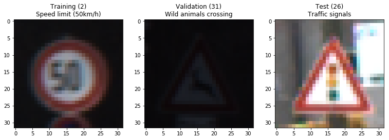

```python
### Data exploration visualization code goes here.
### Feel free to use as many code cells as needed
fig = plt.figure(figsize=(10,20))
fig.tight_layout()
fig.add_axes()

random.seed(int(round(time.time() * 1000)))

train_i = np.random.randint(0, n_train-1)
ax0 = fig.add_subplot(1,3,1)
ax0.imshow(X_train[train_i])
ax0.set_title('Training ({})\n{}'.format(y_train[train_i], signName[y_train[train_i]]))

valid_i = np.random.randint(0, n_validation-1)
ax1 = fig.add_subplot(1,3,2)
ax1.imshow(X_valid[valid_i])
ax1.set_title('Validation ({})\n{}'.format(y_valid[valid_i], signName[y_valid[valid_i]]))

test_i = np.random.randint(0, n_test-1)
ax2 = fig.add_subplot(1,3,3)
ax2.imshow(X_test[test_i])
ax2.set_title('Test ({})\n{}'.format(y_test[test_i], signName[y_test[test_i]]))

plt.subplots_adjust(left=0., right=1, top=0.9, bottom=0.)
```

```
The 5 most common signs in the training set are:
[(2, 2010), (1, 1980), (13, 1920), (12, 1890), (38, 1860)]
['Speed limit (50km/h)', 'Speed limit (30km/h)', 'Yield', 'Priority road', 'Keep right']
```

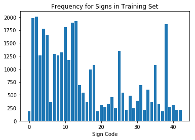

```python
# Count the number of each sign (sign's histogram)
sign_freq_obj = Counter(y_train)
print('The 5 most common signs in the training set are: ')
print(sign_freq_obj.most_common(5))
most_common_label = [signName[i[0]] for i in sign_freq_obj.most_common(5)]
print(most_common_label)

# Plotting frequency of signs (number of occurences for each sign in the training set)
sign_label, sign_freq = zip(*sign_freq_obj.items())    # * for unpacking the containers
plt.bar(sign_label, sign_freq)
plt.title('Frequency for Signs in Training Set')
plt.xlabel('Sign Code')
plt.show()
```

## Step 2: Design and Test a Model Architecture

Design and implement a deep learning model that learns to recognize traffic signs. Train and test your model on the [German Traffic Sign Dataset](http://benchmark.ini.rub.de/?section=gtsrb&subsection=dataset).

The LeNet-5 implementation shown in the classroom at the end of the CNN lesson is a solid starting point. You'll have to change the number of classes and possibly the preprocessing, but aside from that it's plug and play!

With the LeNet-5 solution from the lecture, you should expect a validation set accuracy of about 0.89. To meet specifications, the validation set accuracy will need to be at least 0.93. It is possible to get an even higher accuracy, but 0.93 is the minimum for a successful project submission.

There are various aspects to consider when thinking about this problem:

- Neural network architecture (is the network over or underfitting?)
- Play around preprocessing techniques (normalization, rgb to grayscale, etc)
- Number of examples per label (some have more than others).
- Generate fake data.

Here is an example of a [published baseline model on this problem](http://yann.lecun.com/exdb/publis/pdf/sermanet-ijcnn-11.pdf). It's not required to be familiar with the approach used in the paper but, it's good practice to try to read papers like these.

### Pre-process the Data Set (normalization, grayscale, etc.)

Minimally, the image data should be normalized so that the data has mean zero and equal variance. For image data, `(pixel - 128)/ 128` is a quick way to approximately normalize the data and can be used in this project.

Other pre-processing steps are optional. You can try different techniques to see if it improves performance.

Use the code cell (or multiple code cells, if necessary) to implement the first step of your project.

```python
### Preprocess the data here. It is required to normalize the data. Other preprocessing steps could include
### converting to grayscale, etc.

# Convert to gray scale using cv2
def grayscale(dataset, isOneImg=False):
    # Input shape = (34799,32,32,1)
    # Output shape = (34799,32,32)
    if not isOneImg:
        gray = np.zeros((dataset.shape[0], dataset.shape[1], dataset.shape[2]))
        for i in range(len(dataset)):
            gray[i] = cv2.cvtColor(dataset[i], cv2.COLOR_RGB2GRAY)
    else:
        gray = np.copy(dataset)
        gray = cv2.cvtColor(gray, cv2.COLOR_RGB2GRAY)

    return gray

# Normalize images
def normalize(dataset):
    dataset_norm = np.copy(dataset).astype(float)
    for i in range(len(dataset)):
        dataset_norm[i] = (dataset_norm[i]-128)/128
    return dataset_norm

# ============== Image Augmentation ==============
# 1. Adding salt and pepper noise
# 2. Rotating, scaling, resize, translation, center, etc.
# 3. Generate new data for the low-frequency labels
# 4. Random brightness, random contrast, random saturation, random jpeg quality

# Gaussian Noise -> affect lighting conditions !!!
def add_gaussian_noise(gray):
    row, col = gray.shape
    mu, sigma = 0, 0.001**0.5
    gauss = np.random.normal(mu, sigma, (row,col))
    gauss = gauss.reshape(row, col)
    noisy = gray+gauss
    return noisy

def add_salt_pepper_noise(gray):
    s_vs_p = 0.5
    amount = 0.004
    noisy = np.copy(gray)

    # Salt mode
    num_salt = np.ceil(amount * gray.size * s_vs_p)
    coords = [np.random.randint(0, i - 1, int(num_salt))
          for i in gray.shape]
    noisy[coords] = 1

    # Pepper mode
    num_pepper = np.ceil(amount* gray.size * (1. - s_vs_p))
    coords = [np.random.randint(0, i - 1, int(num_pepper))
          for i in gray.shape]
    noisy[coords] = 0
    return noisy

def add_speckle_noise(gray):
    row,col = gray.shape
    gauss = np.random.randn(row,col,ch)
    gauss = gauss.reshape(row,col,ch)
    noisy = gray + gray * gauss
    return noisy

def rotate(gray, deg):
    # deg is in degree (not radian)
    row, col = gray.shape
    M = cv2.getRotationMatrix2D((col/2, row/2), deg, 1)
    dst = cv2.warpAffine(gray, M, (col,row))
    return dst

def random_brightness(gray):
    temp_img = np.copy(gray)
    temp_img = tf.image.random_brightness(temp_img, max_delta=0.3)
    temp_img = tf.Session().run(temp_img)     # convert back from tensor to numpy array
    return temp_img

def random_contrast(color):
    temp_img = np.copy(color)
    temp_img = tf.image.random_contrast(temp_img, lower=2, upper=10)
    temp_img = tf.Session().run(temp_img)     # convert back from tensor to numpy array
    return temp_img

def random_saturation(color):
    '''
    Convert image from RGB to HSV tha adjust S channel and clipping
    Convert back to RGB and return
    '''
    temp_img = np.copy(color)
    temp_img = tf.image.random_saturation(temp_img, lower=0, upper=20)
    temp_img = tf.Session().run(temp_img)     # convert back from tensor to numpy array
    return temp_img

def add_dimension(dataset):
    # Input shape = (32799,32,32)
    # Output shape = (32799,32,32,1)
    temp = dataset[:, np.newaxis]
    dataset = np.reshape(temp, (temp.shape[0], temp.shape[2], temp.shape[3], temp.shape[1]))
    return dataset
```

```python
# Dictionary that stores index for each label in training set
index_dict = dict.fromkeys(range(n_classes))
for idx, lb in enumerate(y_train):
    try:
        index_dict[lb].append(idx)
    except:
        index_dict[lb] = [idx]
```

[figure not shown]

```python
# Testing Pre-processing on Color Image
check_img = X_train[0]
m = random_contrast(check_img)
# m = random_saturation(check_img)

fig = plt.figure(figsize=(7,7))
fig.tight_layout()
fig.add_axes()

ax0 = fig.add_subplot(1,2,1)
ax0.imshow(check_img, cmap='gray')
ax0.set_title('{}'.format(signName[y_train[0]]))

ax1 = fig.add_subplot(1,2,2)
ax1.imshow(m, cmap='gray')
ax1.set_title('{}'.format(signName[y_train[0]]))

plt.subplots_adjust(left=0., right=1, top=0.9, bottom=0.)
```

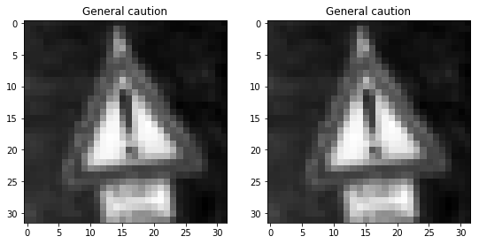

```python
# Testing Pre-processing on Grayscale Image
# Try different image augmentation techniques (add gaussian noise, salt&pepper noise, rotate)
temp_idx = np.random.randint(0, n_train-1)
temp_img_orig = grayscale(X_train[temp_idx], isOneImg=True)
temp_img = random_brightness(temp_img_orig)
temp_img = add_gaussian_noise(temp_img)
# temp_img = add_salt_pepper_noise(temp_img)
# temp_img = rotate(temp_img, deg=random.uniform(-1, 1)*30)

# temp_img = temp_img_orig[:, np.newaxis]
# temp_img = np.reshape(temp_img, (temp_img.shape[0], temp_img.shape[2], temp_img.shape[1]))
# temp_img = tf.image.random_jpeg_quality(temp_img_orig, min_jpeg_quality=10, max_jpeg_quality=90)
# temp_img = tf.squeeze(temp_img)
# temp_img = tf.Session().run(temp_img)

fig = plt.figure(figsize=(7,7))
fig.tight_layout()
fig.add_axes()

ax0 = fig.add_subplot(1,2,1)
ax0.imshow(temp_img_orig, cmap='gray')
ax0.set_title('{}'.format(signName[y_train[temp_idx]]))

ax1 = fig.add_subplot(1,2,2)
ax1.imshow(temp_img, cmap='gray')
ax1.set_title('{}'.format(signName[y_train[temp_idx]]))

plt.subplots_adjust(left=0., right=1, top=0.9, bottom=0.)
# print(temp_img_orig)
# print(temp_img)
```

```python
# # Save new training dataset for easier access
# def save_augmented_img(file_name, X_train_extended, y_train_extended):
#     # EX: file_name = 'train_data_extend.txt'
#     train_extended = {}
#     train_extended['data'] = X_train_extended
#     train_extended['label'] = y_train_extended
#     with open(file_name, 'w') as outfile:
#         json.dump(train_extended, outfile)
#     print('Done saving...')

# # Total number of images in the training set is 34799 and 43 labels
# # Each label should have at least 34799/43=809 => 1000
# # For labels that occur less than 1000 times, we generate fake images with the following steps:
# # - random select an image with that label
# # - rotate randomly
# # - append to the end of the training set
# print(sign_freq_obj)
# print()

# for label, freq in sign_freq_obj.items():
#     min_img = 500
#     X_train_extended = []
#     y_train_extended = []
#     if (freq < min_img) and (label not in [0,6,16,19,20,21,22,23,24,27,28,29,30,32,34,36,37,39,40,41,42]):
#         num_image_add = min_img - freq
#         print('Start with label {}, initial frequency of {}. Adding {} images...'.format(label, freq, num_image_add))

#         # Randomly choose an image with the current label
#         for i in tqdm(range(num_image_add)):
#             random.seed(int(round(time.time() * 1000)))
#             rand_idx = np.random.randint(0, freq-1)
#             temp_idx = (index_dict[label])[rand_idx]
#             temp_img = np.copy(X_train[temp_idx])

#             # Color Image Augmentation
#             temp_img = random_contrast(temp_img)

#             # Grayscale Image Augmentation
#             temp_img = grayscale(temp_img, isOneImg=True)
#             temp_img = random_brightness(temp_img_orig)      # random brightness
#             temp_img = add_gaussian_noise(temp_img)          # add gaussian noise
#             #temp_img = add_salt_pepper_noise(temp_img)       # add salt pepper noise
#             temp_img = rotate(temp_img, deg=random.uniform(-1, 1)*30)     # random rotate
#             # Up to here, temp_img shape = (32,32)

#             # (32,32) -> (32,32,1)
#             #temp_img = temp_img[:, np.newaxis]
#             #temp_img = np.reshape(temp_img, (temp_img.shape[0], temp_img.shape[2], temp_img.shape[1]))

#             # Adding image and label to the end of training set
#             X_train_extended.append(temp_img.tolist())
#             y_train_extended.append(label.tolist())

#         save_augmented_img('extend_label_{0}.txt'.format(label), X_train_extended, y_train_extended)
#         print('Done with label {}'.format(label))
#         print('---------------------------------')
```

```python
# Pre-processing image

# Convert to gray scale
X_train_gray = grayscale(X_train)
X_valid_gray = grayscale(X_valid)
X_test_gray = grayscale(X_test)
```

```python
# Load JSON file that stores extended training set, if necessary
# X_train_extended, y_train_extended = [], []

for file in os.listdir('augmentation-dataset'):
    if file.endswith('.txt'):
        #file_path = os.path.join('/augmentation-image',file)
        print(file)
        os.chdir('./augmentation-dataset')
        with open(file) as txt_file:
            extended_train_data = json.load(txt_file)
#             X_train_extended.append(extended_train_data['data'])
#             y_train_extended.append(extended_train_data['label'])
            X_temp = np.asarray(extended_train_data['data'])
            y_temp = np.asarray(extended_train_data['label'])
            try:
                X_train_extended = np.concatenate((X_train_extended,X_temp), axis=0)
                y_train_extended = np.concatenate((y_train_extended,y_temp), axis=0)
            except:
                X_train_extended = X_temp
                y_train_extended = y_temp

        os.chdir('../')

print('\nDone loading augmentation dataset for training!')
print(X_train_extended.shape, type(X_train_extended))
print(y_train_extended.shape, type(y_train_extended))
```

```
extend_label_16.txt
extend_label_37.txt
extend_label_0.txt
extend_label_39.txt
extend_label_40.txt
extend_label_42.txt
extend_label_19.txt
extend_label_29.txt
extend_label_34.txt
extend_label_23.txt
extend_label_20.txt
extend_label_21.txt
extend_label_28.txt
extend_label_41.txt
extend_label_24.txt
extend_label_36.txt
extend_label_30.txt
extend_label_22.txt
extend_label_27.txt
extend_label_6.txt
extend_label_32.txt

Done loading augmentation dataset for training!
(4440, 32, 32) <class 'numpy.ndarray'>
(4440,) <class 'numpy.ndarray'>
```

```python
print('Before extension...',X_train_gray.shape, y_train.shape)
X_train_gray = np.concatenate((X_train_gray, X_train_extended), axis=0)
y_train = np.concatenate((y_train, y_train_extended), axis=0)
print('After extension...',X_train_gray.shape, y_train.shape)
```

```
Before extension... (34799, 32, 32) (34799,)
After extension... (39239, 32, 32) (39239,)
```

```python
# Normalize datasets
X_train = normalize(X_train_gray)
X_valid = normalize(X_valid_gray)
X_test = normalize(X_test_gray)

# Add dimension to training data before putting into model (32,32,1) -> (1,32,32,1)
X_train = add_dimension(X_train)
X_valid = add_dimension(X_valid)
X_test = add_dimension(X_test)

# Shuffle the training data at first, then for each new epoch, shuffle again
X_train, y_train = shuffle(X_train, y_train)

print('X_train: {}\ty_train: {}'.format(X_train.shape, y_train.shape))
print('X_valid: {}\ty_valid: {}'.format(X_valid.shape, y_valid.shape))
```

```
X_train: (39239, 32, 32, 1)	y_train: (39239,)
X_valid: (4410, 32, 32, 1)	y_valid: (4410,)
```

```
The 5 most common signs in the training set are:
[(2, 2010), (1, 1980), (13, 1920), (12, 1890), (38, 1860)]
['Speed limit (50km/h)', 'Speed limit (30km/h)', 'Yield', 'Priority road', 'Keep right']
```

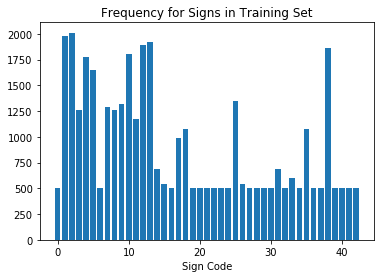

```python
# Count the number of each sign (sign's histogram)
sign_freq_obj = Counter(y_train)
print('The 5 most common signs in the training set are: ')
print(sign_freq_obj.most_common(5))
most_common_label = [signName[i[0]] for i in sign_freq_obj.most_common(5)]
print(most_common_label)
# Plotting frequency of signs (number of occurences for each sign in the training set)
sign_label, sign_freq = zip(*sign_freq_obj.items())    # * for unpacking the containers
plt.bar(sign_label, sign_freq)
plt.title('Frequency for Signs in Training Set')
plt.xlabel('Sign Code')
plt.show()
```

### Model Architecture

```python
### Define your architecture here.
### Feel free to use as many code cells as needed

EPOCHS = 50
BATCH_SIZE = 128
dropout = 0.80  # Dropout, probability to keep units

def LeNet(x):
    # Mean and std dev for truncated normal (normal dist but values whose magnitude is more than
    # 2 std dev from the mean are dropped and re-picked)
    # Need to use truncated_normal instead of random_normal to overcome saturation of some functions like sigmoid
    # where if the value is too big/small, the neurons stops learning
    mu = 0
    sigma = 0.1

    # TODO: Layer 1: Convolutional. Input = 32x32x1. Output = 28x28x6.
    conv1_W = tf.Variable(tf.truncated_normal(shape=(5, 5, 1, 6), mean = mu, stddev = sigma))
    conv1 = tf.nn.conv2d(x, conv1_W, strides=[1,1,1,1], padding='VALID')
    conv1 = tf.nn.bias_add(conv1, tf.Variable(tf.zeros(6)))

    # TODO: Activation.
    conv1 = tf.nn.relu(conv1)

    # TODO: Pooling. Input = 28x28x6. Output = 14x14x6.
    conv1 = tf.nn.max_pool(conv1, ksize=[1,2,2,1], strides=[1,2,2,1], padding='VALID')

    # TODO: Layer 2: Convolutional. Output = 10x10x16.
    conv2_W = tf.Variable(tf.truncated_normal(shape=(5, 5, 6, 16), mean = mu, stddev = sigma))
    conv2 = tf.nn.conv2d(conv1, conv2_W, strides=[1,1,1,1], padding='VALID')
    conv2 = tf.nn.bias_add(conv2, tf.Variable(tf.zeros(16)))

    # TODO: Activation.
    conv2 = tf.nn.relu(conv2)

    # TODO: Pooling. Input = 10x10x16. Output = 5x5x16.
    conv2 = tf.nn.max_pool(conv2, ksize=[1,2,2,1], strides=[1,2,2,1], padding='VALID')

    # Add 1 more convolutional layer. Input = 5x5x16. Ouput = 3x3x32
    conv3_W = tf.Variable(tf.truncated_normal(shape=(3,3,16,32), mean=mu, stddev=sigma))
    conv3 = tf.nn.conv2d(conv2, conv3_W, strides=[1,1,1,1], padding='VALID')
    conv3 = tf.nn.bias_add(conv3, tf.Variable(tf.zeros(32)))
    conv3 = tf.nn.relu(conv3)
    conv3 = tf.nn.max_pool(conv3, ksize=[1,1,1,1], strides=[1,1,1,1], padding='VALID')

    # TODO: Flatten. Input = 3x3x32. Output = 288
    conv_out = tf.contrib.layers.flatten(conv3)
    conv_out = tf.nn.dropout(conv_out, dropout)

    # ----------------------------------------------------------------------------------------
    # TODO: Layer 3: Fully Connected. Input = 288. Output = 120
    fc1_W = tf.Variable(tf.truncated_normal(shape=(288, 120), mean = mu, stddev = sigma))
    fc1_b = tf.Variable(tf.zeros(120))
    fc1 = tf.matmul(conv_out, fc1_W) + fc1_b

    # TODO: Activation.
    fc1 = tf.nn.relu(fc1)
    fc1 = tf.nn.dropout(fc1, dropout)

    # TODO: Layer 4: Fully Connected. Input = 120. Output = 84
    fc2_W = tf.Variable(tf.truncated_normal(shape=(120, 84), mean = mu, stddev = sigma))
    fc2_b = tf.Variable(tf.zeros(84))
    fc2 = tf.matmul(fc1, fc2_W) + fc2_b

    # TODO: Activation.
    fc2 = tf.nn.relu(fc2)
    fc2 = tf.nn.dropout(fc2, dropout)

    # Add one more fully connected layer. Input = 84, output = 64
    fc3_W = tf.Variable(tf.truncated_normal(shape=(84, 64), mean = mu, stddev = sigma))
    fc3_b = tf.Variable(tf.zeros(64))
    fc3 = tf.matmul(fc2, fc3_W) + fc3_b
    fc3 = tf.nn.relu(fc3)
    fc3 = tf.nn.dropout(fc3, dropout)

    # TODO: Layer 5: Fully Connected. Input = 64. Output = 43
    fc4_W = tf.Variable(tf.truncated_normal(shape=(64, n_classes), mean = mu, stddev = sigma))
    fc4_b = tf.Variable(tf.zeros(n_classes))
    logits = tf.add(tf.matmul(fc3, fc4_W), fc4_b)

    return logits
```

### Train, Validate and Test the Model

A validation set can be used to assess how well the model is performing. A low accuracy on the training and validation sets imply underfitting. A high accuracy on the training set but low accuracy on the validation set implies overfitting.

```python
### Train your model here.
### Calculate and report the accuracy on the training and validation set.
### Once a final model architecture is selected,
### the accuracy on the test set should be calculated and reported as well.
### Feel free to use as many code cells as needed.

# Features and Labels
# Placeholder for batch of input images and batch of output labels
x = tf.placeholder(tf.float32, (None, 32, 32, 1))
y = tf.placeholder(tf.int32, (None))
one_hot_y = tf.one_hot(y, n_classes)

learning_rate = 0.001
logits  = LeNet(x)
cross_entropy = tf.nn.softmax_cross_entropy_with_logits(labels=one_hot_y, logits=logits)
loss_operation = tf.reduce_mean(cross_entropy)
optimizer = tf.train.AdamOptimizer(learning_rate = learning_rate)
training_operation = optimizer.minimize(loss_operation)

# predict = tf.nn.softmax(logits)
top_5_predict = tf.nn.top_k(tf.nn.softmax(logits), k=5)
```

```python
# Model Evaluation
correct_prediction = tf.equal(tf.argmax(logits, 1), tf.argmax(one_hot_y, 1))
accuracy_operation = tf.reduce_mean(tf.cast(correct_prediction, tf.float32))
saver = tf.train.Saver()

def evaluate(X_data, y_data):
    num_examples = len(X_data)
    num_batches = np.ceil(num_examples/BATCH_SIZE)
    total_accuracy = 0
    total_loss = 0
    sess = tf.get_default_session()
    for offset in range(0, num_examples, BATCH_SIZE):
        end = offset + min(BATCH_SIZE, num_examples-offset)
        batch_x, batch_y = X_data[offset:end], y_data[offset:end]
        accuracy = sess.run(accuracy_operation, feed_dict={x: batch_x, y: batch_y})
        #total_accuracy += (accuracy * len(batch_x))
        total_accuracy += accuracy

        loss = sess.run(loss_operation, feed_dict={x: batch_x, y: batch_y})
        total_loss += loss

    return total_accuracy/num_batches, total_loss/num_batches
```

```python
# Train the Model
acc = np.NINF
train_loss_list = []
valid_loss_list = []

with tf.Session() as sess:
    sess.run(tf.global_variables_initializer())
    num_examples = len(X_train)
    num_batches = np.ceil(num_examples/BATCH_SIZE)

    print("...Start training...")
    print()
    for i in range(EPOCHS):
        train_loss = 0

        X_train, y_train = shuffle(X_train, y_train)
        for offset in range(0, num_examples, BATCH_SIZE):
            end = offset + min(BATCH_SIZE, num_examples-offset)
            batch_x, batch_y = X_train[offset:end], y_train[offset:end]
            _, current_loss = sess.run([training_operation, loss_operation], feed_dict={x: batch_x, y: batch_y})

            # update total training loss
            train_loss += current_loss

        # Calculate average losses
        train_loss = train_loss/num_batches

        # Validation
        validation_accuracy, validation_loss = evaluate(X_valid, y_valid)
        print("EPOCH {} ...".format(i+1))
        print('Train Loss = {}\tValidation Loss = {}'.format(train_loss, validation_loss))
        print("Validation Accuracy = {:.3f}".format(validation_accuracy))
        train_loss_list.append(train_loss)
        valid_loss_list.append(validation_loss)

        # Save model
        if acc < validation_accuracy:
            acc = validation_accuracy
            saver.save(sess, 'lenet.ckpt')
            print("==> Model saved")
        print('--------- End current Epoch ---------')
```

```
...Start training...

EPOCH 1 ...
Train Loss = 2.8642976357804835	Validation Loss = 1.699616483279637
Validation Accuracy = 0.515
==> Model saved
--------- End current Epoch ---------
EPOCH 2 ...
Train Loss = 1.2727270400097006	Validation Loss = 0.8969650034393583
Validation Accuracy = 0.715
==> Model saved
--------- End current Epoch ---------
EPOCH 3 ...
Train Loss = 0.8641917187150215	Validation Loss = 0.7449415930679866
Validation Accuracy = 0.780
==> Model saved
--------- End current Epoch ---------
EPOCH 4 ...
Train Loss = 0.7072164348359994	Validation Loss = 0.5984354926007135
Validation Accuracy = 0.824
==> Model saved
--------- End current Epoch ---------
EPOCH 5 ...
Train Loss = 0.6158623050789103	Validation Loss = 0.5230028631431716
Validation Accuracy = 0.858
==> Model saved
--------- End current Epoch ---------
EPOCH 6 ...
Train Loss = 0.5465907404981918	Validation Loss = 0.4991123538996492
Validation Accuracy = 0.875
==> Model saved
--------- End current Epoch ---------
EPOCH 7 ...
Train Loss = 0.5036076831506984	Validation Loss = 0.4412704824869122
Validation Accuracy = 0.882
==> Model saved
--------- End current Epoch ---------
EPOCH 8 ...
Train Loss = 0.4766531963301792	Validation Loss = 0.4415874118783644
Validation Accuracy = 0.881
```

[output cut: 168 more lines]

```
Train Loss = 0.2883061505247405	Validation Loss = 0.3263863373373169
Validation Accuracy = 0.938
--------- End current Epoch ---------
EPOCH 48 ...
Train Loss = 0.2948122631260937	Validation Loss = 0.3257279657692249
Validation Accuracy = 0.936
--------- End current Epoch ---------
EPOCH 49 ...
Train Loss = 0.2891400804203186	Validation Loss = 0.33473434346628245
Validation Accuracy = 0.944
--------- End current Epoch ---------
EPOCH 50 ...
Train Loss = 0.28735615679514914	Validation Loss = 0.36547236362738267
Validation Accuracy = 0.932
--------- End current Epoch ---------
```

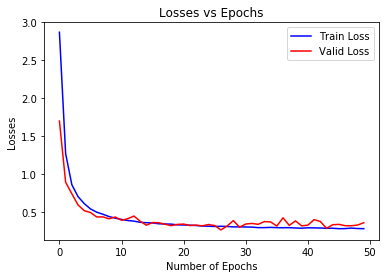

```python
# Losses vs Epochs
train_loss_arr = np.asarray(train_loss_list)
valid_loss_arr = np.asarray(valid_loss_list)
plt.plot(range(EPOCHS), train_loss_arr, 'b')
plt.plot(range(EPOCHS), valid_loss_arr, 'r')
plt.legend(['Train Loss', 'Valid Loss'])
plt.xlabel('Number of Epochs')
plt.ylabel('Losses')
plt.title('Losses vs Epochs')
plt.show()
```

## Step 3: Test a Model on New Images

To give yourself more insight into how your model is working, download at least five pictures of German traffic signs from the web and use your model to predict the traffic sign type.

You may find `signnames.csv` useful as it contains mappings from the class id (integer) to the actual sign name.

### Load and Output the Images

```
['test-images/sign0.jpg', 'test-images/sign5.jpg', 'test-images/sign9.jpg', 'test-images/sign7.jpg', 'test-images/sign1.jpg', 'test-images/sign4.jpg', 'test-images/sign2.jpg', 'test-images/sign6.jpg', 'test-images/sign3.jpg', 'test-images/sign8.jpg']
```

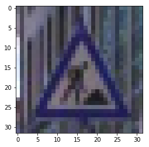

```python
### Load the images and plot them here
test_img_list = os.listdir("test-images/")
test_img_list = [t for t in test_img_list if not t.startswith('.')]
test_img_list = [x[0]+x[1] for x in zip(['test-images/']*len(test_img_list), test_img_list)]
print(test_img_list)

my_test_dataset = np.empty((len(test_img_list),32,32,3), dtype=np.uint8)
for i, t in enumerate(test_img_list):
    # Load image as size (400,400,3) -> resize to (32,32,3)
    img = mpimg.imread(t)
    #resized_img = cv2.resize(img, None, fx=1/12.5, fy=1/12.5, interpolation=cv2.INTER_AREA)
    resized_img = cv2.resize(img, (32,32), interpolation=cv2.INTER_AREA)
    #img = image.load_img(test_img_list[1], target_size=(32,32))
    #img_arr = np.uint8(image.img_to_array(img))
    my_test_dataset[i] = resized_img

plt.imshow(my_test_dataset[0], cmap='gray')
plt.show()
```

### Predict the Sign Type for Each Image

```python
### Run the predictions here and use the model to output the prediction for each image.
### Make sure to pre-process the images with the same pre-processing pipeline used earlier
def pre_process(img_set):
    # Convert to grayscale
    gray = grayscale(img_set, isOneImg=False)

    # Normalize
    normalized_img = normalize(gray)

    # Add dimension (32x32x1) -> (1x32x32x1)
    pre_processed_set = add_dimension(normalized_img)

    return pre_processed_set

test_set = pre_process(my_test_dataset)
print(test_set.shape)
```

```
(10, 32, 32, 1)
```

```python
saver = tf.train.Saver()
save_file = 'lenet.ckpt'
with tf.Session() as sess:
    saver.restore(sess, save_file)

    # Output all 43 predicted probabilities for each image
    prediction = sess.run(top_5_predict, feed_dict={x: test_set})

    # Check on original test set
    prediction_testset = sess.run(top_5_predict, feed_dict={x: X_test})
    accuracy_testset,_ = evaluate(X_test, y_test)
    print('Accuracy on Test set: {:.3f}'.format(accuracy_testset))
```

```
INFO:tensorflow:Restoring parameters from lenet.ckpt
Accuracy on Test set: 0.920
```

```python
# prediction
```

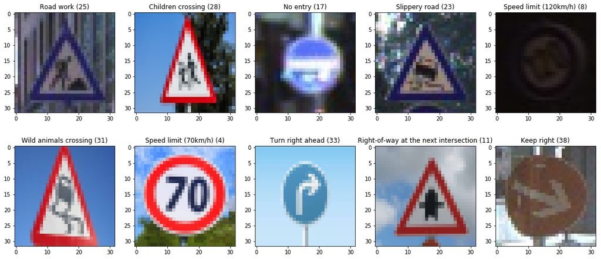

```python
predict_label = prediction[1][:,0]

fig = plt.figure(figsize=(15,7))
fig.tight_layout()
fig.add_axes()

for idx,temp in enumerate(my_test_dataset):
    ax = fig.add_subplot(2,len(my_test_dataset)/2,idx+1)
    ax.imshow(temp, cmap='gray')
    ax.set_title('{} ({})'.format(signName[predict_label[idx]], predict_label[idx]))

plt.subplots_adjust(left=0., right=1, top=0.9, bottom=0.)
```

### Make predictions on Test dataset

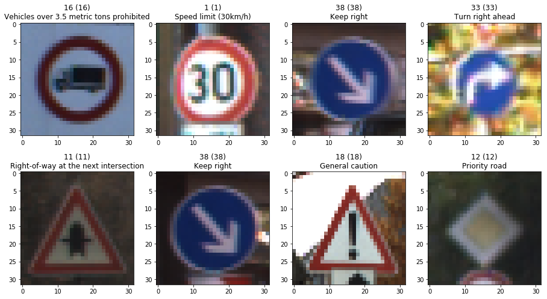

```python
predict_label_testset = prediction_testset[1][:,0]

fig = plt.figure(figsize=(12,7))
fig.tight_layout()
fig.add_axes()

for idx,temp in enumerate(X_test_orig[:8]):
    ax = fig.add_subplot(2,len(X_test[:8])/2,idx+1)
    ax.imshow(temp, cmap='gray')
    ax.set_title('{0} ({1})\n{2}'.format(predict_label_testset[idx], y_test[idx], signName[predict_label_testset[idx]]))

plt.subplots_adjust(left=0., right=1, top=0.9, bottom=0.)
```

### Analyze Performance

```python
### Calculate the accuracy for these 5 new images.
### For example, if the model predicted 1 out of 5 signs correctly, it's 20% accurate on these new images

# For this part, we can visualize and determine which prediction is correct by hand
```

[output not shown]

### Output Top 5 Softmax Probabilities For Each Image Found on the Web

For each of the new images, print out the model's softmax probabilities to show the **certainty** of the model's predictions (limit the output to the top 5 probabilities for each image). [`tf.nn.top_k`](https://www.tensorflow.org/versions/r0.12/api_docs/python/nn.html#top_k) could prove helpful here.

The example below demonstrates how tf.nn.top_k can be used to find the top k predictions for each image.

`tf.nn.top_k` will return the values and indices (class ids) of the top k predictions. So if k=3, for each sign, it'll return the 3 largest probabilities (out of a possible 43) and the correspoding class ids.

Take this numpy array as an example. The values in the array represent predictions. The array contains softmax probabilities for five candidate images with six possible classes. `tf.nn.top_k` is used to choose the three classes with the highest probability:

```
# (5, 6) array
a = np.array([[ 0.24879643,  0.07032244,  0.12641572,  0.34763842,  0.07893497,
         0.12789202],
       [ 0.28086119,  0.27569815,  0.08594638,  0.0178669 ,  0.18063401,
         0.15899337],
       [ 0.26076848,  0.23664738,  0.08020603,  0.07001922,  0.1134371 ,
         0.23892179],
       [ 0.11943333,  0.29198961,  0.02605103,  0.26234032,  0.1351348 ,
         0.16505091],
       [ 0.09561176,  0.34396535,  0.0643941 ,  0.16240774,  0.24206137,
         0.09155967]])
```

Running it through `sess.run(tf.nn.top_k(tf.constant(a), k=3))` produces:

```
TopKV2(values=array([[ 0.34763842,  0.24879643,  0.12789202],
       [ 0.28086119,  0.27569815,  0.18063401],
       [ 0.26076848,  0.23892179,  0.23664738],
       [ 0.29198961,  0.26234032,  0.16505091],
       [ 0.34396535,  0.24206137,  0.16240774]]), indices=array([[3, 0, 5],
       [0, 1, 4],
       [0, 5, 1],
       [1, 3, 5],
       [1, 4, 3]], dtype=int32))
```

Looking just at the first row we get `[ 0.34763842, 0.24879643, 0.12789202]`, you can confirm these are the 3 largest probabilities in `a`. You'll also notice `[3, 0, 5]` are the corresponding indices.

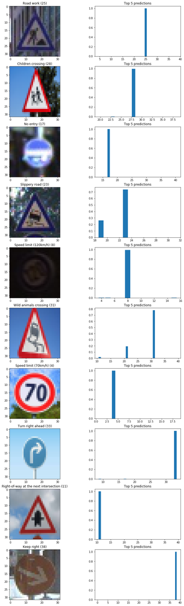

```python
### Print out the top five softmax probabilities for the predictions on the German traffic sign images found on the web
fig = plt.figure(figsize=(10,35))
fig.tight_layout()
fig.add_axes()

for idx,temp in enumerate(my_test_dataset):
    ax0 = fig.add_subplot(len(my_test_dataset),2,2*idx+1)
    ax0.imshow(temp, cmap='gray')
    ax0.set_title('{} ({})'.format(signName[predict_label[idx]], predict_label[idx]))

    ax1 = fig.add_subplot(len(my_test_dataset),2,2*idx+2)
    ax1.bar(prediction[1][idx], prediction[0][idx])
    ax1.set_title('Top 5 predictions')

plt.subplots_adjust(left=0., right=1, top=0.9, bottom=0.)
```

### Project Writeup

Once you have completed the code implementation, document your results in a project writeup using this [template](https://github.com/udacity/CarND-Traffic-Sign-Classifier-Project/blob/master/writeup_template.md) as a guide. The writeup can be in a markdown or pdf file.

## Step 4 (Optional): Visualize the Neural Network's State with Test Images

This Section is not required to complete but acts as an additional excersise for understaning the output of a neural network's weights. While neural networks can be a great learning device they are often referred to as a black box. We can understand what the weights of a neural network look like better by plotting their feature maps. After successfully training your neural network you can see what it's feature maps look like by plotting the output of the network's weight layers in response to a test stimuli image. From these plotted feature maps, it's possible to see what characteristics of an image the network finds interesting. For a sign, maybe the inner network feature maps react with high activation to the sign's boundary outline or to the contrast in the sign's painted symbol.

Provided for you below is the function code that allows you to get the visualization output of any tensorflow weight layer you want. The inputs to the function should be a stimuli image, one used during training or a new one you provided, and then the tensorflow variable name that represents the layer's state during the training process, for instance if you wanted to see what the LeNet lab's feature maps looked like for it's second convolutional layer you could enter conv2 as the tf_activation variable.

For an example of what feature map outputs look like, check out NVIDIA's results in their paper [End-to-End Deep Learning for Self-Driving Cars](https://devblogs.nvidia.com/parallelforall/deep-learning-self-driving-cars/) in the section Visualization of internal CNN State. NVIDIA was able to show that their network's inner weights had high activations to road boundary lines by comparing feature maps from an image with a clear path to one without. Try experimenting with a similar test to show that your trained network's weights are looking for interesting features, whether it's looking at differences in feature maps from images with or without a sign, or even what feature maps look like in a trained network vs a completely untrained one on the same sign image.

[figure not shown]

Your output should look something like this (above)

```python
### Visualize your network's feature maps here.
### Feel free to use as many code cells as needed.

# image_input: the test image being fed into the network to produce the feature maps
# tf_activation: should be a tf variable name used during your training procedure that represents the calculated state of a specific weight layer
# activation_min/max: can be used to view the activation contrast in more detail, by default matplot sets min and max to the actual min and max values of the output
# plt_num: used to plot out multiple different weight feature map sets on the same block, just extend the plt number for each new feature map entry

def outputFeatureMap(image_input, tf_activation, activation_min=-1, activation_max=-1 ,plt_num=1):
    # Here make sure to preprocess your image_input in a way your network expects
    # with size, normalization, ect if needed
    # image_input =
    # Note: x should be the same name as your network's tensorflow data placeholder variable
    # If you get an error tf_activation is not defined it may be having trouble accessing the variable from inside a function
    activation = tf_activation.eval(session=sess,feed_dict={x : image_input})
    featuremaps = activation.shape[3]
    plt.figure(plt_num, figsize=(15,15))
    for featuremap in range(featuremaps):
        plt.subplot(6,8, featuremap+1) # sets the number of feature maps to show on each row and column
        plt.title('FeatureMap ' + str(featuremap)) # displays the feature map number
        if activation_min != -1 & activation_max != -1:
            plt.imshow(activation[0,:,:, featuremap], interpolation="nearest", vmin =activation_min, vmax=activation_max, cmap="gray")
        elif activation_max != -1:
            plt.imshow(activation[0,:,:, featuremap], interpolation="nearest", vmax=activation_max, cmap="gray")
        elif activation_min !=-1:
            plt.imshow(activation[0,:,:, featuremap], interpolation="nearest", vmin=activation_min, cmap="gray")
        else:
            plt.imshow(activation[0,:,:, featuremap], interpolation="nearest", cmap="gray")
```